# Compare EMT from 6-hr pressure versus monthly product

EE Holmes

11/20/2020

Keep in mind that the land is masked some years and not others.

```
## data read from /Users/eli.holmes/Documents/GitHub/SardineForecast/inst/extdata/get_satellite_data/Replicate_EMT/erdlasFnWPr-7-15-70-78-1970-01-01-2019-01-01.csv
## data erdlasFnWPr date 1970-01-01-2019-01-01, latitude 7-15, longitude 70-78
```

Whether or not the land is masked varies so make sure to only use points over water.

For the years 1970 to 1980, the calculations in the monthly ERD product are the means of the 6-hour data. Plot shown for one point but it is similar across other points.

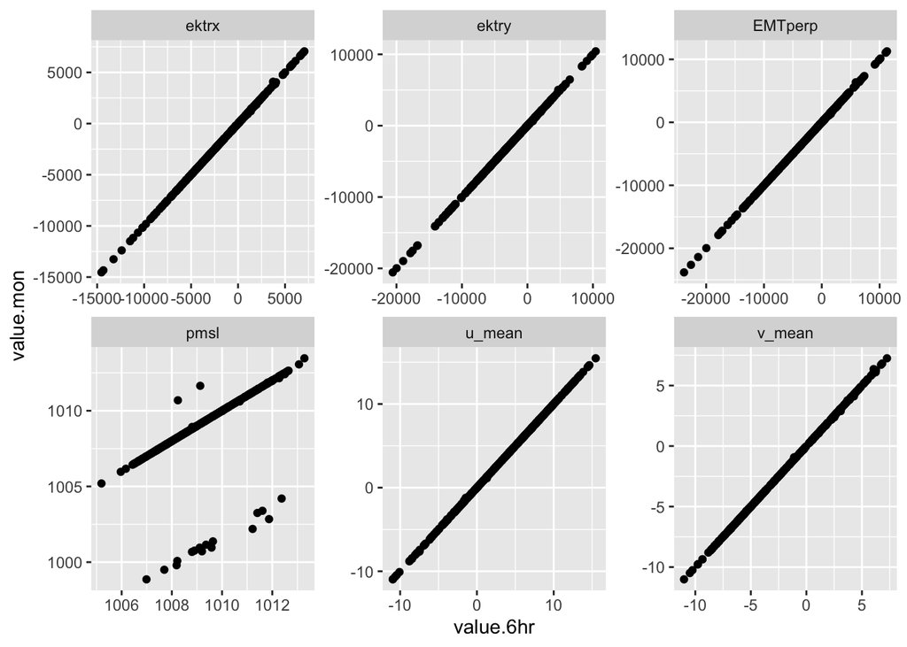

However for 1981 to 1996, the v wind calculation is quite different. The mean pressure values are very similar but the v wind is different. Shown for one point but similar for other latitudes and longitudes.

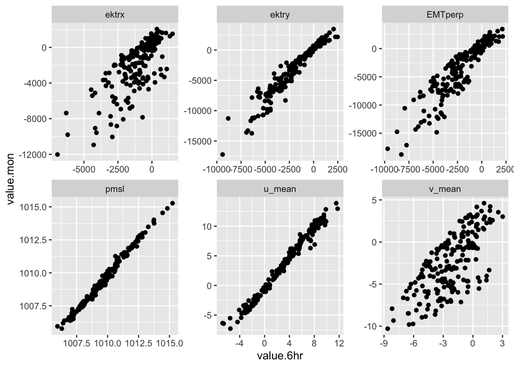

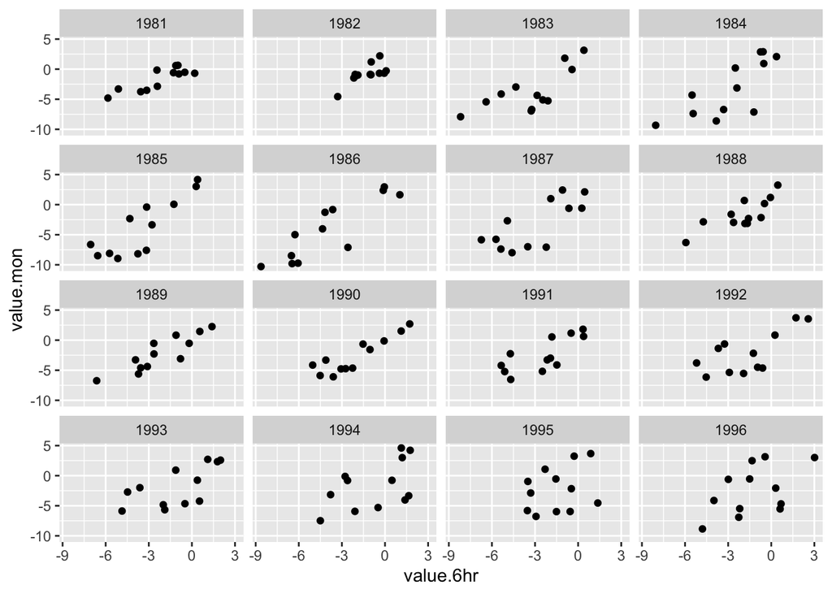

Monthly means for all the variables.

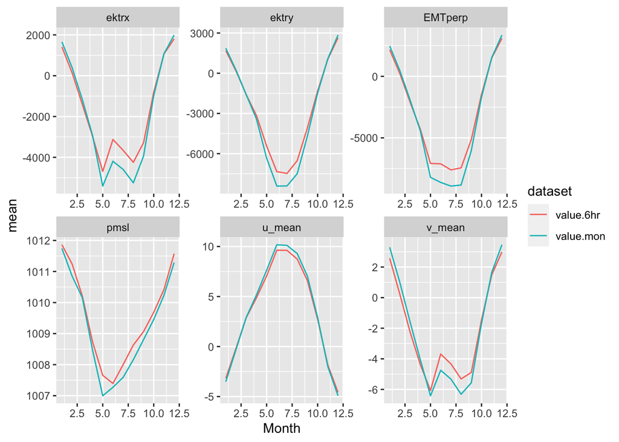

Differences in monthly means across years.

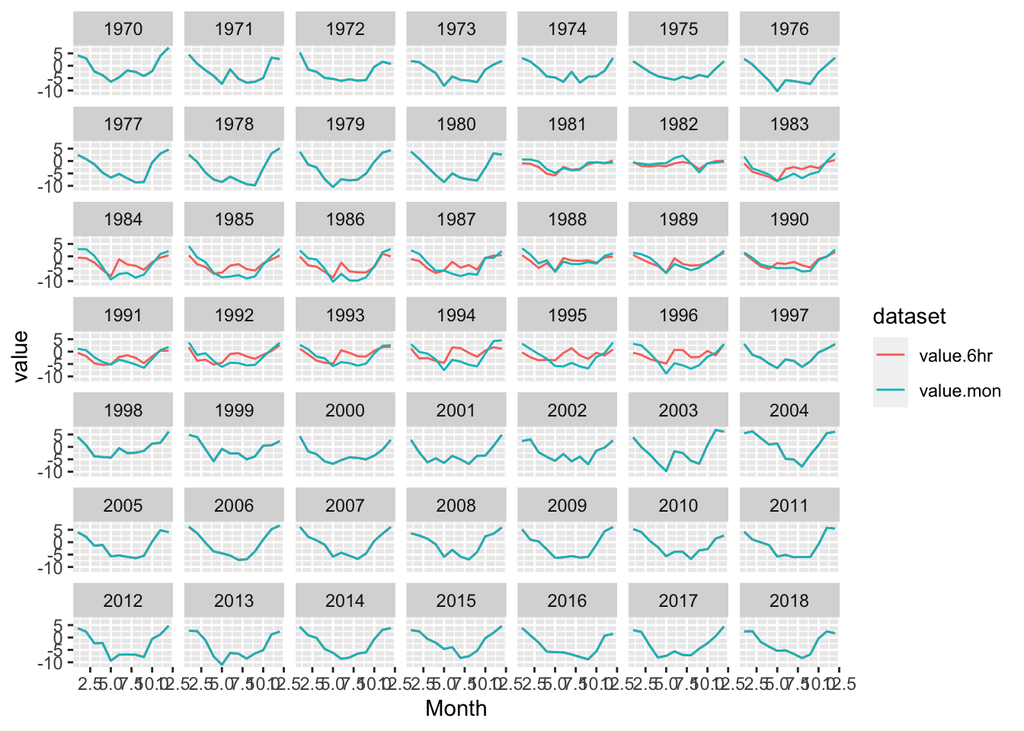

Here are the values for July at latitude 11.5 and longitude 75.5.

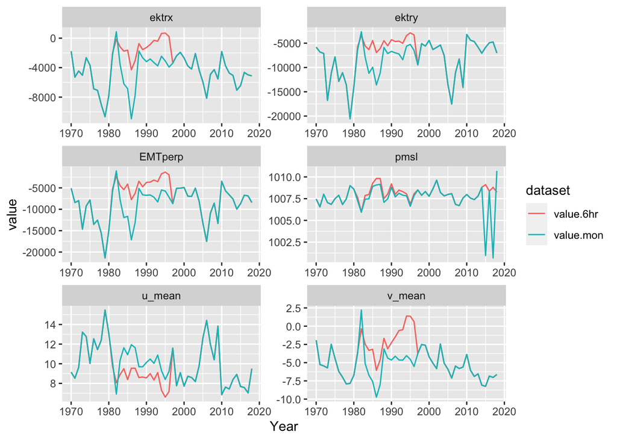

Here are the values for July at different latitudes.

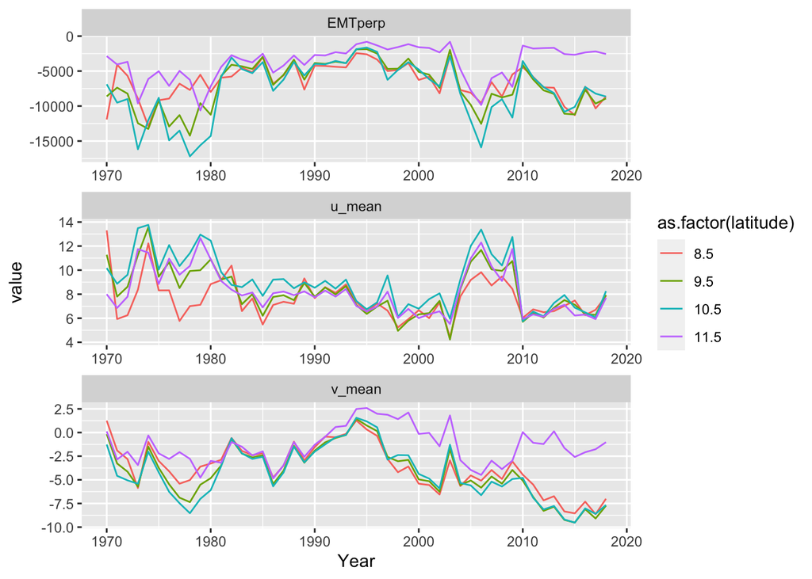

# Try to replicate Figure 2 in Manjusha et al 2019

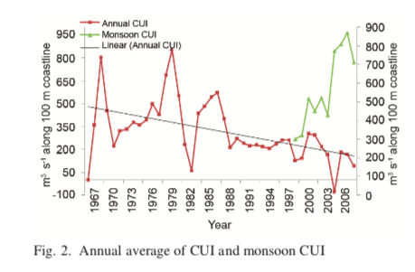

The text says it uses the ERD upwelling index at latitude 8.5N and longitude 76.5E approx. But that doesn’t seem right.

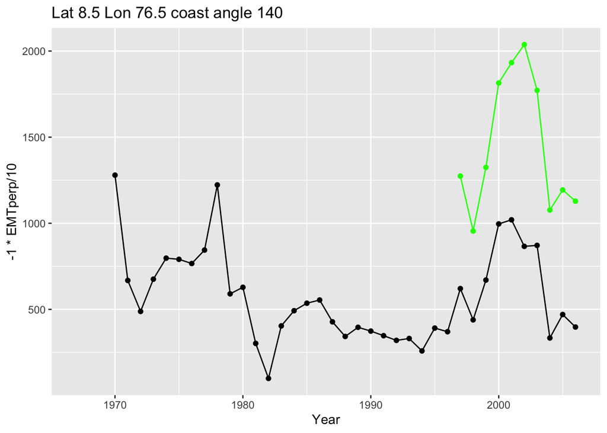

While at latitude 11.5 and longitude 75.5, it appear fairly similar. The scales are very similar. Mine is kg/ms while theirs is m3/s over 100m of coastline and the sign is reversed. So to translate to the same scale -1 x my.number kg/ms x 100m / 1029 kg/m3 = m3/s over 100m of coastline. The density of sea water is 1029 kg/m3. The thin grey line is the averages from the 6 hour data, but they used the monthly data from ERD. As noted above I don’t know why 1982 to 1996 is different than the 6-hour averages. It is unclear what coast angle they used. They give both 140 and 133, which would be roughly that near 11.5 degrees latitude.

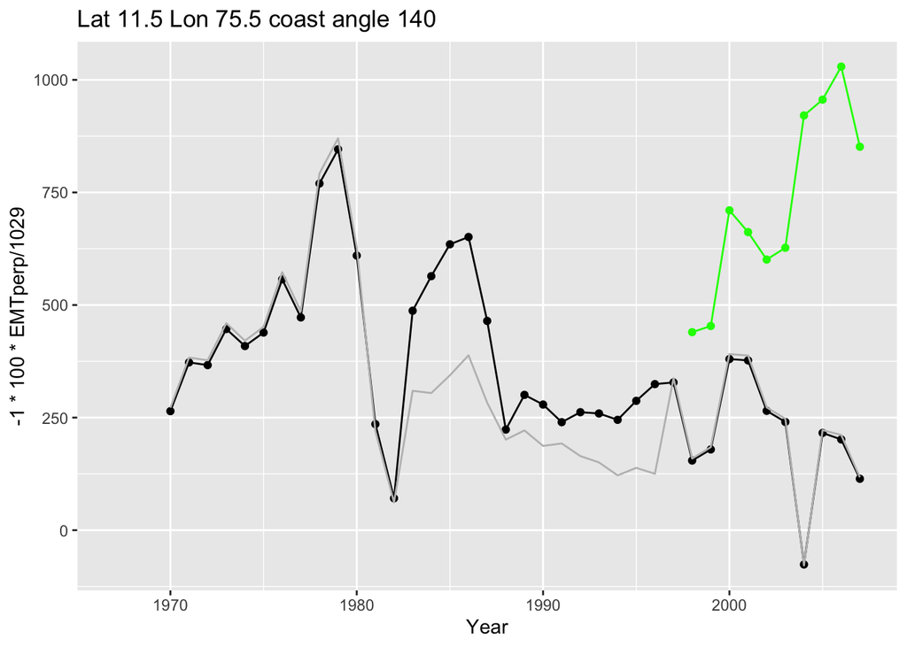